# Component Interpretation Summary via SDA

D.E. Beaudette

2023-03-21

You probably need to install some packages before this will work. Have a look at [this tutorial](http://ncss-tech.github.io/AQP/soilDB/SDA-tutorial.html) to get setup.

Lets get some interpretations that are relevant to MLRA 18 (Sierra Nevada Foothills) soils so that we can compare all components named [**Amador**](https://casoilresource.lawr.ucdavis.edu/sde/?series=amador) and [**Millvilla**](https://casoilresource.lawr.ucdavis.edu/sde/?series=millvilla). Just for fun lets throw in a very different soil from MLRA 17 (San Joaquin Valley); [**Hanford**](https://casoilresource.lawr.ucdavis.edu/sde/?series=hanford).

Note that SDA has a 100,000 row limit, so we have to be a little clever when writing the queries. In this case, letting the database filter out NULL fuzzy ratings and the reasons for ratings.

```r
library(aqp)
library(soilDB)
library(reshape2)
library(lattice)
library(cluster)
library(ape)
library(sharpshootR)
library(plyr)


# beware, there are hard limits (100k rows) on what can be returned by SDA
q <- "SELECT component.cokey, compname, mrulename, interplr, interplrc
FROM legend
INNER JOIN mapunit ON mapunit.lkey = legend.lkey
INNER JOIN component ON component.mukey = mapunit.mukey
INNER JOIN cointerp ON component.cokey = cointerp.cokey
WHERE
-- exclude STATSGO
areasymbol != 'US'
AND compname IN ('Millvilla', 'Amador', 'Hanford')
AND seqnum = 0
AND mrulename IN ('ENG - Construction Materials; Topsoil',
'ENG - Sewage Lagoons', 'ENG - Septic Tank Absorption Fields',
'ENG - Unpaved Local Roads and Streets',
'AGR - California Revised Storie Index (CA)')
AND interplr IS NOT NULL;"

# query and check
x <- SDA_query(q)
kable(head(x))
```

| cokey | compname | mrulename | interplr | interplrc |
| --- | --- | --- | --- | --- |
| 22539852 | Hanford | AGR - California Revised Storie Index (CA) | 0.837 | Grade 1 - Excellent |
| 22539852 | Hanford | ENG - Construction Materials; Topsoil | 0.741 | Fair |
| 22539852 | Hanford | ENG - Sewage Lagoons | 0.400 | Somewhat limited |
| 22539852 | Hanford | ENG - Septic Tank Absorption Fields | 0.954 | Somewhat limited |
| 22539852 | Hanford | ENG - Unpaved Local Roads and Streets | 0.400 | Somewhat limited |
| 22539782 | Hanford | AGR - California Revised Storie Index (CA) | 0.796 | Grade 2 - Good |

OK, so how do the fuzzy numbers (`interplr` values) for these components compare?

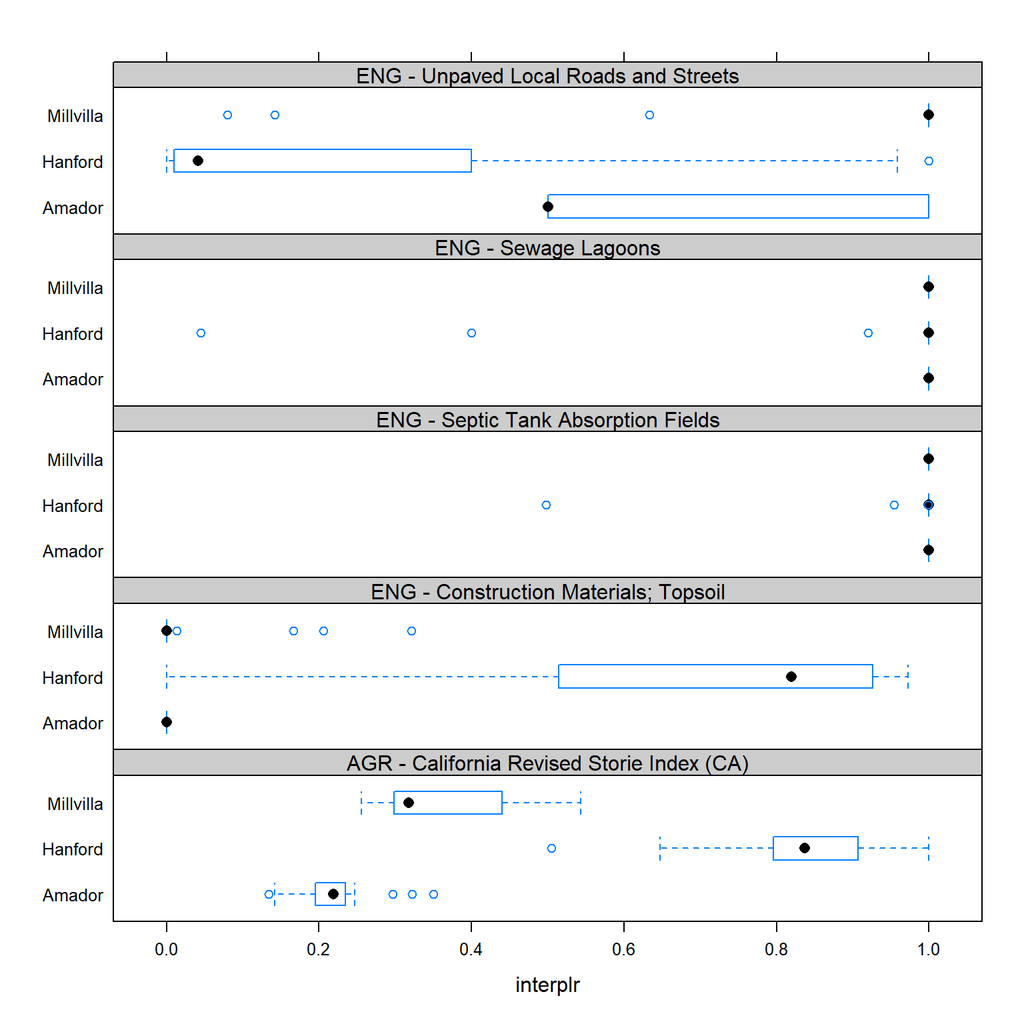

```r
# compute number of rules and soils
n.soils <- length(unique(x$compname))
n.rules <- length(unique(x$mrulename))

# compare population with box-whisker plot
bwplot(compname ~ interplr | mrulename, data=x, layout=c(1,n.rules), strip=strip.custom(bg=grey(0.8)))
```

Those figures were useful, sometimes it is nice to see the median values for each interpretation (rows) and component (columns).

```r
s <- ddply(x, c('mrulename', 'compname'), plyr::summarize,
           low=quantile(interplr, probs=0.05, na.rm=TRUE),
           rv=quantile(interplr, probs=0.5, na.rm=TRUE),
           high=quantile(interplr, probs=0.95, na.rm=TRUE))

knitr::kable(dcast(s, mrulename ~ compname, value.var = 'rv'), caption = "Median Fuzzy Ratings")
```

Median Fuzzy Ratings

| mrulename | Amador | Hanford | Millvilla |
| --- | --- | --- | --- |
| AGR - California Revised Storie Index (CA) | 0.219 | 0.837 | 0.318 |
| ENG - Construction Materials; Topsoil | 0.000 | 0.820 | 0.000 |
| ENG - Septic Tank Absorption Fields | 1.000 | 1.000 | 1.000 |
| ENG - Sewage Lagoons | 1.000 | 1.000 | 1.000 |
| ENG - Unpaved Local Roads and Streets | 0.500 | 0.041 | 1.000 |

What about the categorical ratings? Note that the `kable` function from the **knitr** package makes nice HTML tables for us.

```r
knitr::kable(xtabs(~ interplrc + compname , data=x, subset= mrulename == 'ENG - Construction Materials; Topsoil'), caption="ENG - Construction Materials; Topsoil")
```

ENG - Construction Materials; Topsoil

|  | Amador | Hanford | Millvilla |
| --- | --- | --- | --- |
| Fair | 0 | 95 | 4 |
| Poor | 23 | 10 | 13 |

```r
knitr::kable(xtabs(~ interplrc + compname , data=x, subset= mrulename == 'AGR - California Revised Storie Index (CA)'), caption = "AGR - California Revised Storie Index (CA)'")
```

AGR - California Revised Storie Index (CA)’

|  | Amador | Hanford | Millvilla |
| --- | --- | --- | --- |
| Grade 1 - Excellent | 0 | 75 | 0 |
| Grade 2 - Good | 0 | 28 | 0 |
| Grade 3 - Fair | 0 | 2 | 7 |
| Grade 4 - Poor | 14 | 0 | 10 |
| Grade 5 - Very Poor | 9 | 0 | 0 |

```r
knitr::kable(xtabs(~ interplrc + compname , data=x, subset= mrulename == 'ENG - Septic Tank Absorption Fields'), caption = "ENG - Septic Tank Absorption Fields")
```

ENG - Septic Tank Absorption Fields

|  | Amador | Hanford | Millvilla |
| --- | --- | --- | --- |
| Somewhat limited | 0 | 21 | 0 |
| Very limited | 23 | 84 | 17 |

```r
knitr::kable(xtabs(~ interplrc + compname , data=x, subset= mrulename == 'ENG - Sewage Lagoons'), caption = "ENG - Sewage Lagoons")
```

ENG - Sewage Lagoons

|  | Amador | Hanford | Millvilla |
| --- | --- | --- | --- |
| Somewhat limited | 0 | 18 | 0 |
| Very limited | 23 | 87 | 17 |

## Interpretation Based Similarity

Here is a crazy idea, what if we could sort a collection of soil series based on a subset of relevant interpretations? We can, as long as some assumptions are made:

1. there exists a small set of interpretations that reliably describe some aspect of “similarity”
2. the mean fuzzy rating is a realistic description of central tendency
3. in aggregate, the collection of components named for a soil series will approximate the central tendency of that series

Lets try it with a small set of MLRA 17, 18, and 22A soils. NULL ratings will confound interpretation of the results–there are no “AGR - Pesticide Loss Potential-Leaching” ratings for components named “Dunstone”. I have tried to select a small set of relevant interpretations, but clearly there are many possibilities. Soil profile sketches ([derived from Official Series Descriptions](http://ncss-tech.github.io/AQP/soilDB/soil-series-query-functions.html)) are used in the final figure. Note that these are not the same as the component data that were used to generate the interpretation-based similarity.

```r
# set list of soil series (component names)
soil.list <- c('Pardee', 'Yolo', 'Capay', 'Aiken', 'Amador', 'Pentz', 'Sobrante',
'Argonaut', 'Toomes', 'Jocal', 'Holland', 'Auburn', 'Dunstone',
'Hanford', 'Redding', 'Columbia', 'San Joaquin', 'Fresno')

# set list of relevant interpretations
interp.list <- c('ENG - Construction Materials; Topsoil',
'ENG - Sewage Lagoons', 'ENG - Septic Tank Absorption Fields',
'ENG - Unpaved Local Roads and Streets',
'AGR - California Revised Storie Index (CA)')

# compose query
q <- paste0("SELECT compname, mrulename, AVG(interplr) as interplr_mean
FROM legend
INNER JOIN mapunit ON mapunit.lkey = legend.lkey
INNER JOIN component ON component.mukey = mapunit.mukey
INNER JOIN cointerp ON component.cokey = cointerp.cokey
WHERE
-- exclude STATSGO
areasymbol != 'US'
AND compname IN ", format_SQL_in_statement(soil.list), "
AND seqnum = 0
AND mrulename IN ", format_SQL_in_statement(interp.list), "
AND interplr IS NOT NULL
GROUP BY compname, mrulename;")

# send query
x <- SDA_query(q)

# reshape long -> wide
x.wide <- dcast(x, compname ~ mrulename, value.var = 'interplr_mean')
knitr::kable(x.wide, digits = 3, caption="Mean Fuzzy Ratings for Select Soil Series")
```

Mean Fuzzy Ratings for Select Soil Series

| compname | AGR - California Revised Storie Index (CA) | ENG - Construction Materials; Topsoil | ENG - Septic Tank Absorption Fields | ENG - Sewage Lagoons | ENG - Unpaved Local Roads and Streets |
| --- | --- | --- | --- | --- | --- |
| Aiken | 0.737 | 0.211 | 1.000 | 0.972 | 0.794 |
| Amador | 0.226 | 0.000 | 1.000 | 1.000 | 0.691 |
| Argonaut | 0.441 | 0.124 | 1.000 | 1.000 | 0.994 |
| Auburn | 0.299 | 0.001 | 1.000 | 1.000 | 0.997 |
| Capay | 0.505 | 0.166 | 1.000 | 0.819 | 1.000 |
| Columbia | 0.610 | 0.445 | 0.958 | 0.962 | 0.850 |
| Dunstone | 0.233 | 0.000 | 1.000 | 1.000 | 0.788 |
| Fresno | 0.140 | 0.000 | 1.000 | 1.000 | 0.399 |
| Hanford | 0.845 | 0.694 | 0.987 | 0.872 | 0.209 |
| Holland | 0.601 | 0.100 | 0.981 | 0.999 | 0.880 |
| Jocal | 0.617 | 0.075 | 0.938 | 0.994 | 0.938 |
| Pardee | 0.246 | 0.000 | 1.000 | 1.000 | 1.000 |
| Pentz | 0.247 | 0.003 | 1.000 | 1.000 | 0.707 |
| Redding | 0.300 | 0.021 | 1.000 | 1.000 | 0.797 |
| San Joaquin | 0.263 | 0.204 | 1.000 | 1.000 | 0.542 |
| Sobrante | 0.438 | 0.071 | 1.000 | 1.000 | 0.859 |
| Toomes | 0.175 | 0.000 | 1.000 | 1.000 | 1.000 |
| Yolo | 0.828 | 0.846 | 0.906 | 0.614 | 0.608 |

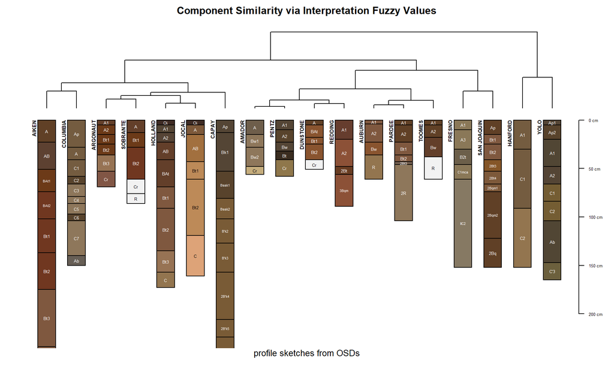

```r
# set row names to uppercase compname
# this will allow us to integrate with an SPC of OSD data later
row.names(x.wide) <- toupper(x.wide$compname)

# create distance matrix
# leave out compname
d <- daisy(x.wide[, -1])

# cluster via divisive hierachical method
# labels are recovered from row names -> distance matrix dimnames
h <- diana(d)

# fetch typical profiles from official series descriptions
osds <- fetchOSD(soil.list)

# magic happens here
# hang profile sketches from interpretation-based clustering
# may have to tinker with arguments to get figure right
par(mar=c(2,1,2,1))
plotProfileDendrogram(osds, clust = diana(d), scaling.factor = 0.008, max.depth=200, width = 0.3, name.style = 'center-center', shrink = TRUE)
title('Component Similarity via Interpretation Fuzzy Values')
mtext('profile sketches from OSDs', side = 1)
```

Interesting. Discussion to be continued…

This document is based on `soilDB` version 2.7.7.